# Capacidad de carros por consumo

GLM Gaussiano

Author

Asael Alonzo Matamoros

Published

November 16, 2022

La base de datos `mtcars` contiene el registro de motores de carros mas populares en USA, 1974. los datos contienen 32 registros, con 10 atributos del motor.

```r
library(caret)
library(GGally)
library(ggplot2)
library(flextable)
library(bayesplot)
library(ggfortify)
```

Se desea predecir la capacidad de consumo de los motores, para eso se evaluaron las siguiente variables.

- `mpg`: Millas por Galón. (**Dependiente**)
- `hp`: Caballos de fuerza.
- `carb`: número de carburadores.
- `wt`: peso del motor.
- `gears`: Número de cambios.
- `vs`: tipo de motor, `recto:1` o `tipo V:0`.

## Verosimilitud

Para medir la relación de consumo de los motores utilizaremos un GLM normal tal que:

$$mpg_i \sim N(\mu_i,\sigma^2), \quad g(\mu_i) = \mu_i, \text{ y } \mu_i = \beta X_i.$$

El siguiente código limpia la base de datos para obtener las variables de interés

```r
df = mtcars[,c(1,4,6,8,10,11)]
str(df)
```

```
'data.frame':   32 obs. of  6 variables:
 $ mpg : num  21 21 22.8 21.4 18.7 18.1 14.3 24.4 22.8 19.2 ...
 $ hp  : num  110 110 93 110 175 105 245 62 95 123 ...
 $ wt  : num  2.62 2.88 2.32 3.21 3.44 ...
 $ vs  : num  0 0 1 1 0 1 0 1 1 1 ...
 $ gear: num  4 4 4 3 3 3 3 4 4 4 ...
 $ carb: num  4 4 1 1 2 1 4 2 2 4 ...
```

Todas las variables son numéricas, pero algunas son totalmente enteras, dificultando el proceso de análisis, se procede a revisar las correlaciones para revisar las interacciones lineales entre variables.

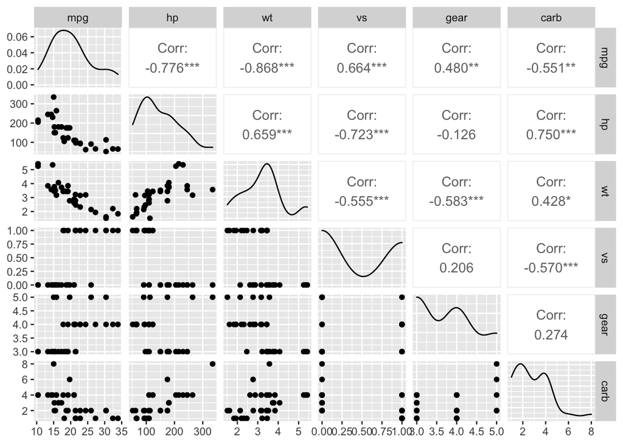

Figure 1: Gráfico de pares. La diagonal principal muestra histogramas densidades de cada una de las variables. La parte superior muestra el coeficiente de correlación entre dos variables, fila y columna. La parte inferior muestra un gráfico de dispersión entre dos variables.

```r
ggpairs(df)
```

Figure 1 muestra colinealidad entre las variables `mpg, hp` y `wt`. Por lo tanto, múltiples modelos deben ser considerados. Realizemos un modelo inicial, el considerado el modelo completo que posee todas las variables

**Colinealidad**

Dos covariables $X_1$ y $X_2$ se dicen ser **colineales** si las variables son **linealmente dependientes**.

Recordar que si dos columnas de una matriz son linealmente dependiente, entonces el determinante es cero.

## Ajuste del modelo

Ajustamos el modelo completo que consiste en usar todas las variables, y revisamos el ajuste e inferencia de los parámetros.

```r
m1 = lm(mpg~.,data = df)
summary(m1)
```

```
Call:
lm(formula = mpg ~ ., data = df)

Residuals:
    Min      1Q  Median      3Q     Max
-3.2884 -1.4370 -0.3155  1.1697  5.8246

Coefficients:
            Estimate Std. Error t value Pr(>|t|)
(Intercept) 27.20311    5.74212   4.737 6.72e-05 ***
hp          -0.02339    0.01353  -1.728   0.0958 .
wt          -2.74663    0.92005  -2.985   0.0061 **
vs           0.94692    1.36929   0.692   0.4954
gear         1.78520    1.12762   1.583   0.1255
carb        -0.65498    0.57767  -1.134   0.2672
---
Signif. codes:  0 '***' 0.001 '**' 0.01 '*' 0.05 '.' 0.1 ' ' 1

Residual standard error: 2.569 on 26 degrees of freedom
Multiple R-squared:  0.8477,    Adjusted R-squared:  0.8184
F-statistic: 28.94 on 5 and 26 DF,  p-value: 7.653e-10
```

Debido a la alta colinealidad entre las variables, pocos parámetros estimados son significativos. Procedemos a eliminar algunas variables del modelo. Eliminamos la variable `wt` al ser colineal con múltiples variables. Por lo tanto, el modelo inicial $M_1$ es:

```r
m1  =  lm(mpg~vs+hp+gear+carb,data = df)
summary(m1)
```

```
Call:
lm(formula = mpg ~ vs + hp + gear + carb, data = df)

Residuals:
    Min      1Q  Median      3Q     Max
-3.8047 -2.3487 -0.0967  1.9188  6.7859

Coefficients:
            Estimate Std. Error t value Pr(>|t|)
(Intercept) 13.03756    3.67694   3.546  0.00145 **
vs           0.84671    1.55657   0.544  0.59093
hp          -0.03449    0.01480  -2.331  0.02747 *
gear         4.20129    0.89285   4.705 6.72e-05 ***
carb        -1.33338    0.60391  -2.208  0.03593 *
---
Signif. codes:  0 '***' 0.001 '**' 0.01 '*' 0.05 '.' 0.1 ' ' 1

Residual standard error: 2.921 on 27 degrees of freedom
Multiple R-squared:  0.7955,    Adjusted R-squared:  0.7652
F-statistic: 26.25 on 4 and 27 DF,  p-value: 5.825e-09
```

## Incertidumbre de los estimadores.

Pese que la función `lm` de `R` realiza un análisis de incertidumbre al presentar una *Prueba-t* de significacia para cada parámetro $\beta_i$, no presenta los intervalos de confianza. Estos serán estimados con **Bootstrap**. La siguiente función obtiene una muestra Bootstrap de los parámetros desconocidos $\beta$.

```r
lm_boots = function(y,x,B = 1000){
  n = length(y)
  est = NULL
  for (i in 1:B) {
    si = sample(x = 1:n,size = n,replace = TRUE)
    mli = lm(y[si]~x[si,] )
    ci = as.array(mli$coefficients)
    est = rbind(est,ci)
  }
  # Estética
  cn = colnames(x)
  colnames(est) = c("intercepto",cn)

  return(est)
}
```

Obtenemos una muestra Bootstrap para los estimadores $\hat \beta$ de tamaño $B=5,000$ repeticiones

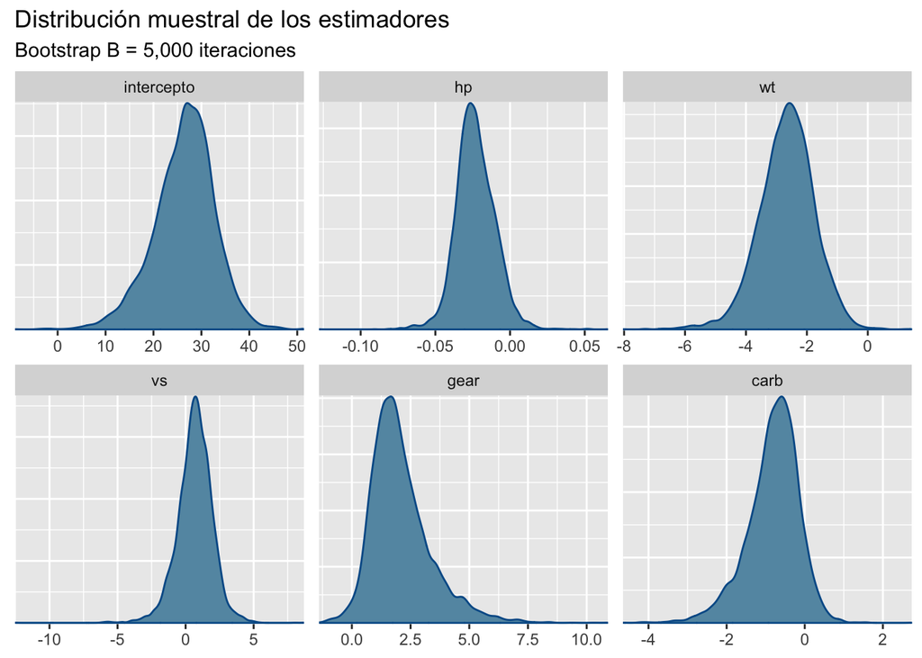

Figure 2: Gráfico de densidades. Cada densidad representa la distribución muestral aproximada para cada uno de los estimadores usando un Bootstrap de B=5,000 iteraciones.

```r
btp = lm_boots(y = df$mpg,x = as.matrix(df[,-1]),B = 5000)

bayesplot_theme_set(theme_grey())
mcmc_dens(btp)+labs(title="Distribución muestral de los estimadores",
                    subtitle ="Bootstrap B = 5,000 iteraciones")
```

Los intervalos de confianza al 95% son:

```r
x = apply(btp,MARGIN = 2, FUN = quantile, probs = c(0.025,0.5,0.975))

# Estética
x = data.frame( t(x) )
x$pars = c("intercepto","hp","wt","vs","gear","carb")
colnames(x) = c("q2.5%","Median","q97.5%","parámetros")

ft = flextable(x[c(4,1,2,3)])
autofit(ft)
```

Table 1: Intervalos de confianza al 95%, obtenidos a partir de una muestra bootstrap de B = 5,000 iteraciones

| parámetros | q2.5% | Median | q97.5% |
| --- | --- | --- | --- |
| intercepto | 12.49972248 | 26.8327631 | 37.820121815 |
| hp | -0.04733468 | -0.0238692 | 0.003186784 |
| wt | -4.54781142 | -2.6217014 | -0.970003207 |
| vs | -2.04724071 | 0.7297319 | 3.079382071 |
| gear | 0.18618829 | 1.8492681 | 5.257749540 |
| carb | -2.34699720 | -0.7398896 | 0.297693999 |

Los intervalos de confianza revelan mayor información a lo obtenido por la prueba-t, parámetros como `hp`, y `carb` que son significativos en la prueba, no lo son mediante los intervalos. Esto indica la posibilidad de un modelo mucho mas reducido.

## Análisis de los residuos

Una vez evaluadas las estimaciones del modelo, es necesario revisar los residuos del mismo para corroborar supuestos, la siguiente linea de código presenta un resumen descriptivo de los residuos del modelo inicial $M_1$, en su mayoría parecen estar centrados en cero.

```r
summary(m1$residuals)
```

```
    Min.  1st Qu.   Median     Mean  3rd Qu.     Max.
-3.80470 -2.34875 -0.09674  0.00000  1.91880  6.78592
```

Figure 3 presenta una visualización típica para el diagnostico de los residuos, ninguna figura debe presentar un comportamiento polinómico a excepción del gráfico de quantiles (*derecha superior*), que debe seguir el comportamiento de una función lineal creciente.

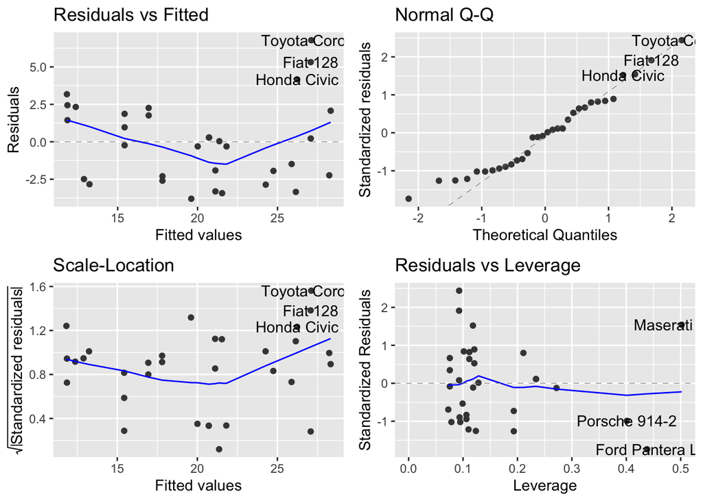

Figure 3: Gráfico diagnóstico de los residuos, estos cuatro gráficos evaluan el ajuste y supuestos del modelo, si algún comportamiento polinómico es persistente, entonces los supuestos del modelo no se satisfacen.

```r
autoplot(m1)
```

## Selección de modelos

Adicional al modelo $M_1$, ajustamos dos modelos mas:

$$M_2: \quad mpg \sim N(hp+gear+carb,\sigma^2),$$
$$M_3: \quad mpg \sim N(wt+gear+carb,\sigma^2).$$

```r
m2 = lm(mpg~hp+gear+carb,data = df)
m3 = lm(mpg~wt+gear+carb,data = df)
```

El siguiente código calcula el $RMSE$ de un modelo linea en el conjunto de entrenamiento.

```r
rmse = function(m){
  mse = sum(m$residuals^2)/length(m$residuals)
  return(sqrt(mse))
}
```

```r
x = matrix(0,nrow = 4,ncol = 3)
x[1,] = c(logLik(m1),logLik(m2),logLik(m3))
x[2,] = c(AIC(m1),AIC(m2),AIC(m3))
x[3,] = c(BIC(m1),BIC(m2),BIC(m3))
x[4,] = c(rmse(m1),rmse(m2),rmse(m3))

# Estética
x = data.frame(x)
x$pars =  c("logLik","AIC","BIC","RMSE")
colnames(x)  = c("Modelo 1","Modelo 2","Modelo 3","Criterio")

ft = flextable(x[c(4,1,2,3)])
autofit(ft)
```

Table 2: Criterios de información de los modelos. Se selecciona el modelo con menores criterios.

| Criterio | Modelo 1 | Modelo 2 | Modelo 3 |
| --- | --- | --- | --- |
| logLik | -76.986353 | -77.160742 | -75.196419 |
| AIC | 165.972706 | 164.321484 | 160.392838 |
| BIC | 174.767122 | 171.650163 | 167.721517 |
| RMSE | 2.682864 | 2.697525 | 2.536917 |

Table 2 muestra la tabla de criterios de información para el conjunto de datos `mtcars` para sorpresa del lector el mejor modelo es el alternativo $M_3$ que usa la variable colineal `wt` en vez de `hp`.

## Validación cruzada

```r
kfold = function(df,k){
  # Generar la particion
  kfld = createFolds(df[,1],k = k)
  mat = NULL

  for (i in 1:k) {
    # separar los datos en conjuntos de prueba y entrenamiento
    dfE= df[-kfld[[i]],]
    dfP = df[kfld[[i]],]
    # Ajustar los modelos
    m1 = lm(mpg~vs+hp+gear+carb,data = dfE)
    m2 = lm(mpg~hp+gear+carb,data = dfE)
    m3 = lm(mpg~wt+gear+carb,data = dfE)

    p1 = predict(m1,dfP)
    p2 = predict(m2,dfP)
    p3 = predict(m3,dfP)
    # Calcular AIC y RMSE
    aic = c(
            AIC(m1),
            AIC(m2),
            AIC(m3)
            )
    rmse = c(
             RMSE(pred =  p1,obs = dfP[,1]),
             RMSE(pred =  p2,obs = dfP[,1]),
             RMSE(pred =  p3,obs = dfP[,1])
             )
    mae = c(
            MAE(pred =  p1,obs = dfP[,1]),
            MAE(pred =  p2,obs = dfP[,1]),
            MAE(pred =  p3,obs = dfP[,1])
            )
    mape = c(
              mean(abs((p1-dfP[,1])/dfP[,1])),
              mean(abs((p2-dfP[,1])/dfP[,1])),
              mean(abs((p3-dfP[,1])/dfP[,1]))
              )
    # Unir los datos
    mat = rbind(mat,c(aic,rmse,mae,mape))
  }
  colnames(mat) = c("AIC1","AIC2","AIC3","RMSE1","RMSE2","RMSE3","MAE1","MAE2",
                    "MAE3","MAPE1","MAPE2","MAPE3")
  row.names(mat) = NULL
  return(mat)
}
```

```r
rst = kfold(df = df,k = 5)
t(apply(rst,MARGIN = 2,FUN = "quantile",probs = c(0.025,0.5,0.975)))
```

```
              2.5%          50%       97.5%
AIC1  122.85813966 134.43262495 140.0269874
AIC2  123.04504583 132.54604629 138.0311124
AIC3  120.50928926 128.37056701 136.6102608
RMSE1   2.18167902   3.22845177   4.2360384
RMSE2   2.16325731   3.26796885   4.0892424
RMSE3   1.21277149   2.78945555   4.1519742
MAE1    1.86735205   3.02207360   3.5455924
MAE2    1.84562806   2.78325288   3.2405314
MAE3    0.96232203   2.08834250   3.8009664
MAPE1   0.09884955   0.15194970   0.1851436
MAPE2   0.09800128   0.13856604   0.1707037
MAPE3   0.05201971   0.09158652   0.2051521
```

## Referencias

Casella, George, and Roger Berger. 2001. *Statistical Inference*. Duxbury Resource Center. http://www.amazon.fr/exec/obidos/ASIN/0534243126/citeulike04-21.

DeGroot, M. H., and M. J. Schervish. 2012. *Probability and Statistics*. Addison-Wesley. https://books.google.es/books?id=4TlEPgAACAAJ.

Gelman, A., J. B. Carlin, H. S. Stern, D. B. Dunson, A. Vehtari, and D. B. Rubin. 2013. *Bayesian Data Analysis, Third Edition*. Chapman & Hall/CRC Texts in Statistical Science. Taylor & Francis. https://books.google.nl/books?id=ZXL6AQAAQBAJ.

Migon, Helio, Dani Gamerman, and Francisco Louzada. 2014. *Statistical Inference. An Integrated Approach*. Chapman and Hall CRC Texts in Statistical Science. Chapman; Hall.

Roback, paul., and Julie. Legler. 2021. *Beyond Multiple Linear Regression: Applied Generalized Linear Models an Multilevel Models in R*. Boca Raton.